# Practical Machine Learning: Weight Lifting Exercise

Park

9/5/2020

## Executive Summary

This is the course project of the third class in the Statistics and Machine Learning Specialization, taught in Coursera.

This analysis uses various measurements from accelerometers on the belt, forearm, arm, and dumbbell of 6 participants. Then, using a machine learning algorithms to predict which class of activity they were performing. There are 5 possible classes (A-E), of which only A means the participants exercised correctly. The remaining classes represent different types of weight lifting exercise, but all were done wrongly.

There are 3 different algorithms in use to decide which performs the most accurately, namely classification tree, random forest and boosting. From this, the random forest method is, by far, the most accurate model with **2.51** out-of-sample error rate.

## Raw Data and Preprocess

### Download Raw Data

There are 2 raw data files that needed to be downloaded into R. First, the training set which will be used to **build** the model. Second, the validating set which will be used to **validate** the model. Note that both files are in the *.csv* format.

```r
#download the file
if (!file.exists("./training.csv")) {
download.file(url = "https://d396qusza40orc.cloudfront.net/predmachlearn/pml-training.csv", destfile = "./training.csv")
}
if (!file.exists("./validating.csv")) {
download.file(url = "https://d396qusza40orc.cloudfront.net/predmachlearn/pml-testing.csv", destfile = "./validating.csv")
}

#read into R
training <- read.csv("training.csv")
validating <- read.csv("validating.csv")
```

Although the *validating* set should not be looked until the model is finalized and the prediction is asked, the data set must undergo the same transformations or pre-processions as the *training* set.

### Preprocess Raw Data

```r
names(training)
```

```
##   [1] "X"                        "user_name"
##   [3] "raw_timestamp_part_1"     "raw_timestamp_part_2"
##   [5] "cvtd_timestamp"           "new_window"
##   [7] "num_window"               "roll_belt"
##   [9] "pitch_belt"               "yaw_belt"
##  [11] "total_accel_belt"         "kurtosis_roll_belt"
##  [13] "kurtosis_picth_belt"      "kurtosis_yaw_belt"
##  [15] "skewness_roll_belt"       "skewness_roll_belt.1"
##  [17] "skewness_yaw_belt"        "max_roll_belt"
##  [19] "max_picth_belt"           "max_yaw_belt"
##  [21] "min_roll_belt"            "min_pitch_belt"
##  [23] "min_yaw_belt"             "amplitude_roll_belt"
##  [25] "amplitude_pitch_belt"     "amplitude_yaw_belt"
##  [27] "var_total_accel_belt"     "avg_roll_belt"
##  [29] "stddev_roll_belt"         "var_roll_belt"
```

[output cut: 65 more lines]

The above output listed all of the variable names recorded in the data set. Since this analysis only interests in the *belt, forearm, arm and dumbbell* parts to predict the *classe* variable, others should be discarded as irrelevant. Thus, select only the columns with these names from **both** data sets.

```r
column <- grep(pattern = ".belt.*|.arm.*|.dumbbell.*|classe", x = names(training))
training <- subset(training, select = column)
validating <- subset(validating, select = column)
```

Let’s preview the data.

```r
training[23:25,]
```

```
##    roll_belt pitch_belt yaw_belt total_accel_belt kurtosis_roll_belt
## 23      1.56       8.10    -94.3                3
## 24      1.51       8.10    -94.4                3           5.587755
## 25      1.53       8.11    -94.4                3
##    kurtosis_picth_belt kurtosis_yaw_belt skewness_roll_belt
## 23
## 24             #DIV/0!           #DIV/0!           2.713152
## 25
##    skewness_roll_belt.1 skewness_yaw_belt max_roll_belt max_picth_belt
## 23                                                   NA             NA
## 24              #DIV/0!           #DIV/0!         -94.3              3
## 25                                                   NA             NA
##    max_yaw_belt min_roll_belt min_pitch_belt min_yaw_belt amplitude_roll_belt
## 23                         NA             NA                               NA
## 24          5.6         -94.4              3          5.6                 0.1
## 25                         NA             NA                               NA
##    amplitude_pitch_belt amplitude_yaw_belt var_total_accel_belt avg_roll_belt
## 23                   NA                                      NA            NA
## 24                    0             0.0000                    0           1.5
## 25                   NA                                      NA            NA
##    stddev_roll_belt var_roll_belt avg_pitch_belt stddev_pitch_belt
## 23               NA            NA             NA                NA
## 24              0.1             0            8.1                 0
## 25               NA            NA             NA                NA
##    var_pitch_belt avg_yaw_belt stddev_yaw_belt var_yaw_belt gyros_belt_x
## 23             NA           NA              NA           NA         0.02
## 24              0        -94.4               0            0         0.02
## 25             NA           NA              NA           NA         0.03
##    gyros_belt_y gyros_belt_z accel_belt_x accel_belt_y accel_belt_z
## 23            0        -0.02          -21            4           21
## 24            0        -0.02          -20            4           22
## 25            0         0.00          -19            4           21
##    magnet_belt_x magnet_belt_y magnet_belt_z roll_arm pitch_arm yaw_arm
## 23            -4           606          -311     -129      20.7    -161
## 24            -3           601          -318     -129      20.7    -161
## 25            -8           605          -319     -129      20.7    -161
##    total_accel_arm var_accel_arm avg_roll_arm stddev_roll_arm var_roll_arm
## 23              34            NA           NA              NA           NA
## 24              34             0    -128.4898          0.5051       0.2551
## 25              34            NA           NA              NA           NA
```

[output cut: 93 more lines]

```
## 23                NA                   NA                NA              NA
## 24         -63.89388              0.07474           0.00559        -151.449
## 25                NA                   NA                NA              NA
##    stddev_yaw_forearm var_yaw_forearm gyros_forearm_x gyros_forearm_y
## 23                 NA              NA            0.02           -0.02
## 24            0.50254         0.25255            0.03           -0.03
## 25                 NA              NA            0.05           -0.03
##    gyros_forearm_z accel_forearm_x accel_forearm_y accel_forearm_z
## 23           -0.02             194             206            -214
## 24            0.00             193             203            -213
## 25            0.00             191             202            -214
##    magnet_forearm_x magnet_forearm_y magnet_forearm_z classe
## 23              -10              653              467      A
## 24              -11              661              470      A
## 25              -14              667              470      A
```

From above, it is obvious that there are many columns with missing data, which comes in different forms: *NA, space or #DIV/0!*. Any observations consisting of one of these missing data will not be useful for the prediction. So, let’s loop through all of the columns in the *training* set and subset those with missing data out. Again, do the same with the *validating* set.

```r
#identify columns with missing data
miss <- c(); none <- c(); nan <- c()
for (i in 1:ncol(training)) {
    col <- training[,i]
    missing <- sum(is.na(col))  #detecting NAs
    gotinfo <- grep(pattern = ".+", x = col)    #detecting missing data
    inf <- grep(pattern = "#DIV/0!", x = col)   #detecting division by 0
    if (missing > 0) {miss <- c(miss, i)}
    if (length(gotinfo) != length(col)) {none <- c(none, i)}
    if (length(inf) != 0) {nan <- c(nan,i)}
}

#subset those out
remove <- sort(unique(c(miss, none, nan)))
training <- subset(training, select = -remove)
validating <- subset(validating, select = -remove)
```

Let’s look at the brief structure of the data set after removing unnecessary columns out.

```r
training$classe <- as.factor(training$classe)   #coerce classe to a factor variable
str(training)
```

```
## 'data.frame':    19622 obs. of  53 variables:
##  $ roll_belt           : num  1.41 1.41 1.42 1.48 1.48 1.45 1.42 1.42 1.43 1.45 ...
##  $ pitch_belt          : num  8.07 8.07 8.07 8.05 8.07 8.06 8.09 8.13 8.16 8.17 ...
##  $ yaw_belt            : num  -94.4 -94.4 -94.4 -94.4 -94.4 -94.4 -94.4 -94.4 -94.4 -94.4 ...
##  $ total_accel_belt    : int  3 3 3 3 3 3 3 3 3 3 ...
##  $ gyros_belt_x        : num  0 0.02 0 0.02 0.02 0.02 0.02 0.02 0.02 0.03 ...
##  $ gyros_belt_y        : num  0 0 0 0 0.02 0 0 0 0 0 ...
##  $ gyros_belt_z        : num  -0.02 -0.02 -0.02 -0.03 -0.02 -0.02 -0.02 -0.02 -0.02 0 ...
##  $ accel_belt_x        : int  -21 -22 -20 -22 -21 -21 -22 -22 -20 -21 ...
##  $ accel_belt_y        : int  4 4 5 3 2 4 3 4 2 4 ...
##  $ accel_belt_z        : int  22 22 23 21 24 21 21 21 24 22 ...
##  $ magnet_belt_x       : int  -3 -7 -2 -6 -6 0 -4 -2 1 -3 ...
##  $ magnet_belt_y       : int  599 608 600 604 600 603 599 603 602 609 ...
##  $ magnet_belt_z       : int  -313 -311 -305 -310 -302 -312 -311 -313 -312 -308 ...
##  $ roll_arm            : num  -128 -128 -128 -128 -128 -128 -128 -128 -128 -128 ...
```

[output cut: 39 more lines]

Note that for some variables, the first 10 values are almost or even identical. A predictor is no longer useful if there is no variation in its measurement values. So, let’s check if there is a variable for which the variance is *near zero*.

```r
library(caret)
nearzero <- nearZeroVar(training[,-53], saveMetrics = TRUE) #discard the outcome
identical((nearzero$nzv == FALSE), rep(TRUE, nrow(nearzero)))
```

```
## [1] TRUE
```

A *TRUE* outcome says that there is no variable with near zero variance.

In building and selecting the model, it should be *tested* to see whether it is performing and decide which of the performs the best. Since, the *validating* set should not be touched, another data set must be built to serve this purpose. Hence, the following splits the *training* data set into 2 subsets: *train* and *test* with 3 to 1 ratio.

```r
set.seed(801)   #for reproducibility
inTrain <- createDataPartition(y = training$classe, p = 0.75, list = FALSE)
train <- training[inTrain, ] ; test <- training[-inTrain, ]
```

## Exploratory Data Analysis

Linear correlation coefficient (PMCC) can play an important part in prediction. First, let’s calculate the correlation coefficient between classe (outcome) and all the remaining variables (predictors).

```r
corr <- data.frame(variable = names(train), PMCC = rep(NA, ncol(train)))
for (i in 1:ncol(train) - 1) {
    corr[i,2] <- cor(train[,i], as.numeric(train$classe))
}
corr[which.max(abs(corr$PMCC)),]
```

```
##         variable      PMCC
## 41 pitch_forearm 0.3381079
```

The maximum correlation coefficient is only 0.34 (2dp) which is clearly a *weak* linear relationship. This suggests that any form of linear model is not suitable for this data set.

As per the structure of the data set, it contains 53 variables. If were to use all of them to predict the *classe* outcome, it would be highly computationally demanding and time-consuming. It would be much faster if some of the variables are combined into one.

Without losing useful information, a variable should be combined with those very similar to them. That is, highly correlated variables usually measure similar or the same thing, but maybe in the same(positive PMCC) or opposite(negative PMCC) direction. So, let’s cross-calculate the correlation coefficient and see how many of them are highly correlated.

```r
corrall <- abs(cor(train[,-53])); diag(corrall) <- 0
highcor <- which(corrall > 0.9, arr.ind = TRUE)
length(highcor)/2   #number of pairs with correlation higher than 0.9
```

```
## [1] 22
```

Even with 0.9 (a very strong relationship), there are 22 pairs of variables with a correlation coefficient high than the threshold. Not to mention 0.75 and 0.8, the number will explode.

To compress the number of predictors without losing vital information, the principal component analysis (PCA) is used. First, apply the PCA for all columns and plot the proportion of variance explained by each component.

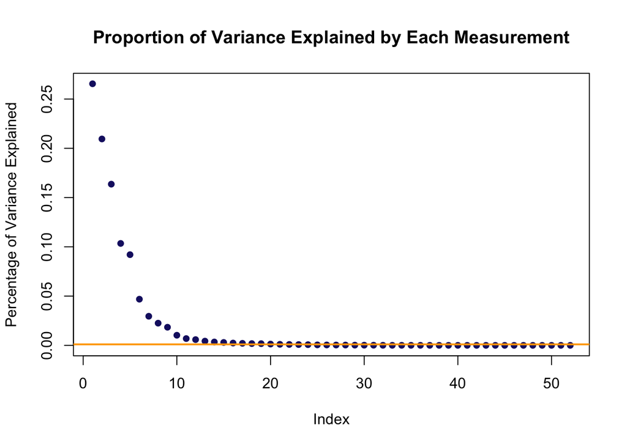

```r
pca <- prcomp(train[,-53])
varex <- pca$sdev^2/sum(pca$sdev^2)
plot(1:52, varex, col = "midnightblue", pch = 16, xlab = "Index",
     ylab = "Percentage of Variance Explained",
     main = "Proportion of Variance Explained by Each Measurement")
abline(h = 0.001, col = "orange", lwd = 2)
```

```r
comp <- length(which(varex >= 0.001))
```

The threshold for useful components will be those which explain at least 0.1% of the total variance in the data set. Next, let’s *preprocess* the *train*, *test* and *validating* sets using PCA. Note that only useful components will be stored in the new data frames.

```r
prep <- preProcess(train[,-53], method = "pca", pcaComp = comp)
trainpca <- predict(prep, train[,-53]); testpca <- predict(prep, test[,-53])
validatingpca <- predict(prep, validating[,-53])

# add the outcome variable into the data frames
trainpca$classe <- train$classe; testpca$classe <- test$classe
validatingpca$classe <- validating$classe
```

## Model Building and Selection

There are 3 models in consideration in this analysis. They are classification trees, random forests and boosting. This is because classification trees can be accurate in non-linear settings whereas random forests and boosting are the 2 most accurate algorithms.

### Cross-Validation

In each of the model, there is a use of **k-fold cross-validation**. It will split the *train* data set in to 5 equal folds. Of this, one is left as the validating set and the remaining 4 is used to fit the model. The process repeats such that every fold gets to be the validating set. Then, the results are averaged. Before getting to the model, let’s set up this setting first.

```r
cvsettings <- trainControl(method = "cv", number = 5, verboseIter = FALSE)
```

### Classification Trees

The first model in concern is the classification trees. This refers to the method *rpart* in the *train* function (caret package). After fitting the model, the dendrogram will visualize the result.

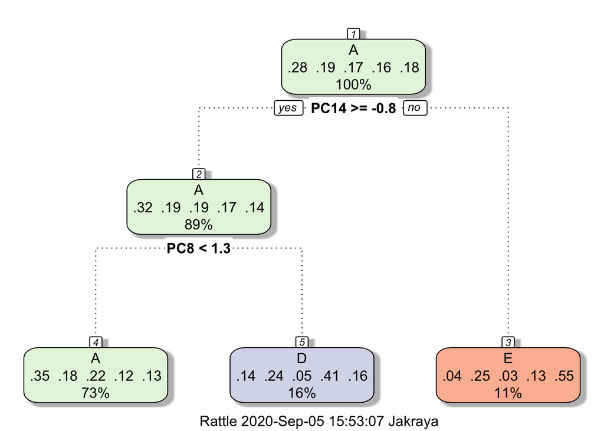

```r
fittree <- train(classe ~ ., data = trainpca, method = "rpart", trControl = cvsettings)
library(rattle); fancyRpartPlot(fittree$finalModel)
```

The algorithm classifies the data into 3 outcome groups: *A,D and E but none to B and C*. This is a sign that may be the algorithm may not work well in this settings. To quantify this, let’s apply the model to the *test* set and evaluate the accuracy.

```r
predtree <- predict(fittree, newdata = testpca)
confusionMatrix(predtree, testpca$classe)
```

```
## Confusion Matrix and Statistics
##
##           Reference
## Prediction    A    B    C    D    E
##          A 1268  644  786  407  490
##          B    0    0    0    0    0
##          C    0    0    0    0    0
##          D  105  190   45  328  126
##          E   22  115   24   69  285
##
## Overall Statistics
##
##                Accuracy : 0.3836
##                  95% CI : (0.3699, 0.3973)
##     No Information Rate : 0.2845
##     P-Value [Acc > NIR] : < 2.2e-16
##
##                   Kappa : 0.1733
##
##  Mcnemar's Test P-Value : NA
##
## Statistics by Class:
##
##                      Class: A Class: B Class: C Class: D Class: E
## Sensitivity            0.9090   0.0000   0.0000  0.40796  0.31632
## Specificity            0.3368   1.0000   1.0000  0.88634  0.94254
## Pos Pred Value         0.3527      NaN      NaN  0.41310  0.55340
## Neg Pred Value         0.9030   0.8065   0.8257  0.88418  0.85965
## Prevalence             0.2845   0.1935   0.1743  0.16395  0.18373
## Detection Rate         0.2586   0.0000   0.0000  0.06688  0.05812
## Detection Prevalence   0.7331   0.0000   0.0000  0.16191  0.10502
## Balanced Accuracy      0.6229   0.5000   0.5000  0.64715  0.62943
```

In the *Overall Statistics* section, the model is only **38.36%** accurate. This is very low and suggests that the model is performing poorly.

### Random Forests

```r
fitrf <- train(classe ~ ., data = trainpca, method = "rf", trControl = cvsettings)
fitrf$finalModel
```

```
##
## Call:
##  randomForest(x = x, y = y, mtry = param$mtry)
##                Type of random forest: classification
##                      Number of trees: 500
## No. of variables tried at each split: 2
##
##         OOB estimate of  error rate: 2.29%
## Confusion matrix:
##      A    B    C    D    E class.error
## A 4152   11   14    6    2 0.007885305
## B   45 2763   35    1    4 0.029845506
## C    5   24 2504   29    5 0.024542267
## D    3    1   91 2312    5 0.041459370
## E    2   16   18   20 2650 0.020694752
```

The *finalModel* section demonstrates that the algorithm uses 500 trees to fit the model. A large number of trees used may be an indicator that the method perform such accurately (estimate of error rate = 2.29%). However, let’s see this in the *test* set.

```r
predrf <- predict(fitrf, newdata = testpca)
confusionMatrix(predrf, testpca$classe)
```

```
## Confusion Matrix and Statistics
##
##           Reference
## Prediction    A    B    C    D    E
##          A 1385   18    4    0    0
##          B    5  915   15    0    4
##          C    2   16  829   33    8
##          D    3    0    7  770    7
##          E    0    0    0    1  882
##
## Overall Statistics
##
##                Accuracy : 0.9749
##                  95% CI : (0.9701, 0.9791)
##     No Information Rate : 0.2845
##     P-Value [Acc > NIR] : < 2.2e-16
##
##                   Kappa : 0.9683
##
##  Mcnemar's Test P-Value : NA
##
## Statistics by Class:
##
##                      Class: A Class: B Class: C Class: D Class: E
## Sensitivity            0.9928   0.9642   0.9696   0.9577   0.9789
## Specificity            0.9937   0.9939   0.9854   0.9959   0.9998
## Pos Pred Value         0.9844   0.9744   0.9336   0.9784   0.9989
## Neg Pred Value         0.9971   0.9914   0.9935   0.9917   0.9953
## Prevalence             0.2845   0.1935   0.1743   0.1639   0.1837
## Detection Rate         0.2824   0.1866   0.1690   0.1570   0.1799
## Detection Prevalence   0.2869   0.1915   0.1811   0.1605   0.1801
## Balanced Accuracy      0.9933   0.9791   0.9775   0.9768   0.9893
```

From above, the algorithm is proved to be **97.49%** accurate on the *test* set. This is much more accurate than the classification trees.

### Boosting

This is the final model that will be taken into consideration for this analysis. Just as before, the same cross-validation settings is used to build the model. Then, apply to the *test* set to evaluate the accuracy.

```r
fitgbm <- train(classe ~ ., data = trainpca, method = "gbm", trControl = cvsettings, verbose = FALSE)
fitgbm$finalModel
```

```
## A gradient boosted model with multinomial loss function.
## 150 iterations were performed.
## There were 21 predictors of which 21 had non-zero influence.
```

The algorithm uses 150 iterations and found that all of the predictors had some influence on the predictions. Not only that it reinforces the fact that all of the PCA components selected are useful, so many iterations may imply that it is accurate (to some extent).

```r
predgbm <- predict(fitgbm, newdata = testpca)
confusionMatrix(predgbm, testpca$classe)
```

```
## Confusion Matrix and Statistics
##
##           Reference
## Prediction    A    B    C    D    E
##          A 1252  108   52   40   20
##          B   27  684   58   25   69
##          C   49  104  704   89   71
##          D   60   30   23  639   37
##          E    7   23   18   11  704
##
## Overall Statistics
##
##                Accuracy : 0.8122
##                  95% CI : (0.801, 0.823)
##     No Information Rate : 0.2845
##     P-Value [Acc > NIR] : < 2.2e-16
##
##                   Kappa : 0.7621
##
##  Mcnemar's Test P-Value : < 2.2e-16
##
## Statistics by Class:
##
##                      Class: A Class: B Class: C Class: D Class: E
## Sensitivity            0.8975   0.7208   0.8234   0.7948   0.7814
## Specificity            0.9373   0.9547   0.9227   0.9634   0.9853
## Pos Pred Value         0.8505   0.7926   0.6922   0.8099   0.9227
## Neg Pred Value         0.9583   0.9344   0.9612   0.9599   0.9524
## Prevalence             0.2845   0.1935   0.1743   0.1639   0.1837
## Detection Rate         0.2553   0.1395   0.1436   0.1303   0.1436
## Detection Prevalence   0.3002   0.1760   0.2074   0.1609   0.1556
## Balanced Accuracy      0.9174   0.8377   0.8730   0.8791   0.8833
```

### Model Selection

It is obvious that the *random forests* algorithm should be used as the final model and applied to the *validating* set. There is no need to fit another model with all the previous predictions as the predictors. This is because the *fitrf* model is highly accurate enough. Combining the predictors will only take more time but yield nearly accurate results as the *fitrf* model.

## Conclusion

The *random forest* algorithm will be used to predict on the *validating set*. Since all of the pre-processes were done prior this, only the model is left to apply.

```
predict(fitrf, newdata = validatingpca)
```

To get an estimate out-of-sample error rate, it is equal to 1 minus the accuracy of the prediction. Since the *validating* set has only 20 observations, it is highly possible that the accuracy will be 100% purely by chance. Hence, 0% out-of-sample error. This suggests that it is not a good representative.

Alternatively, the *test* set will give a much more representative figure as it has a lot more sample size. In addition, the model is not refined after applying to the *test* set. So, the *test* set is not actually counted as part of the data set used to build the model.

```r
#how many observations in the test and validating sets
cbind(dim(test)[1], dim(validating)[1])
```

```
##      [,1] [,2]
## [1,] 4904   20
```

```r
1 - confusionMatrix(predrf, testpca$classe)$overall['Accuracy']
```

```
##   Accuracy
## 0.02508157
```

The out-of-sample error rate is estimated to be **2.51%** (2dp).